# Implications of demographics on income

Sai Ajay Vutukuri, Himani Anil Deshpande, Murali Krishna Parvataneni, Tushar Kant Samantaray

12/8/2021

# 0. Load and Preprocess the data

## Read the data

The data is imported from IPUMS - Source: https://cps.ipums.org/cps/index.shtml Finally extracted columns data - Access: https://drive.google.com/file/d/1R5_A_vr47x8Nw55-c7YbrAy3IJO-qolK/view

## Filtering out the missing data

## Segmenting the industies into 14 categories based on their industry ID’s.

# Creating buckets for different age groups of the employees

# Grouping different education levels into few categories

## Omit any null data after pre-processing

After pre-processing, we have 523452 rows of data.

# 1. Change in unemployement rate over the years in various industires and their affect on income of demographic groups.

### Change in employment rate over the peroid

```
[1] 0.05300582
```

The unemployment rate is about 5.3%, which matches with the real-time data provided by Bureau of Labor Statistics.

## Compute employment percentage of each industry for the years

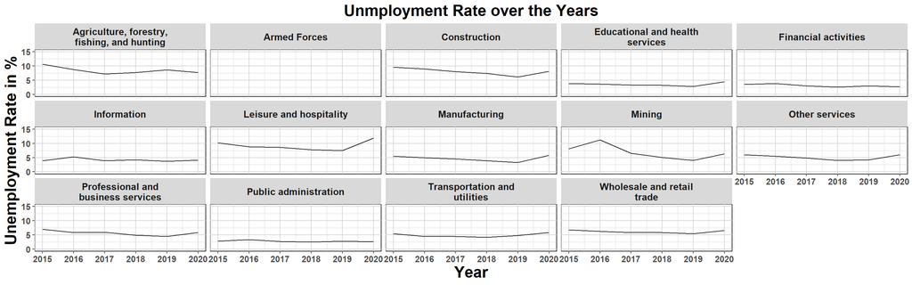

Since people in Active Duty are excluded from CPS data, hence we get 0% employment rate for the Armed Forces. Source: https://www.bls.gov/cps/cps-veterans-faq.htm#:~:text=6.-,Are%20people%20currently%20serving%20on%20active%20duty%20in%20the%20U.S.,the%20CPS%20labor%20force%20estimates.

Therefore, we remove the employment rate of Armed Forces from the data set.

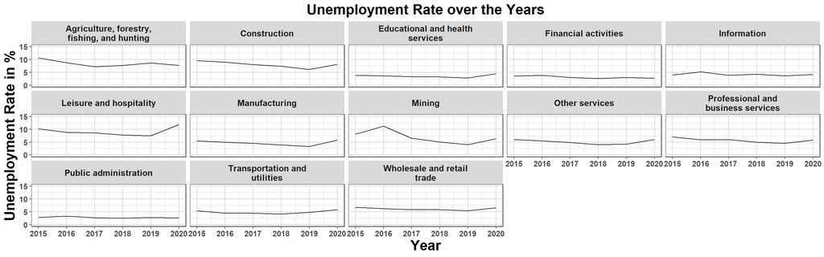

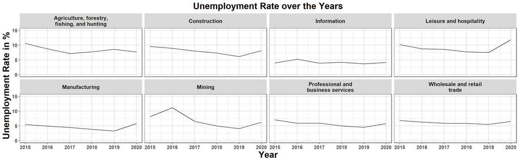